# Practical Machine Learning Project

## Background

Using devices such as Jawbone Up, Nike FuelBand, and Fitbit it is now possible to collect a large amount of data about personal activity relatively inexpensively. One thing that people regularly do is quantify how much of a particular activity they do, but they rarely quantify how well they do it. In this project, goal is to use data from accelerometers on the belt, forearm, arm, and dumbell of 6 participants. They were asked to perform barbell lifts correctly and incorrectly in 5 different ways.

Build model to predict the manner in which they did the exercise from the data.

This is the “classe” variable in the training set and “problem_id” in validation set.

## Data

The training data for this project are available here: https://d396qusza40orc.cloudfront.net/predmachlearn/pml-training.csv The test data are available here: https://d396qusza40orc.cloudfront.net/predmachlearn/pml-testing.csv

## Data Reading

Read the two csv files

```r
train <- read.csv("pml-training.csv", na.strings=c("NA","#DIV/0!",""))
validation  <- read.csv("pml-testing.csv", na.strings=c("NA","#DIV/0!",""))
```

## Data Exploration and Cleanup

We need only numeric data from accelerometers on the belt, forearm, arm, and dumbell. So we select only those columns.

This gives us vector xxx.

The data contains many columns having all zero or all null values. We take sum of columns and get logical vector, sum zero, true or false.

This is vector yyy.

Then we filter these columns to get data for analysis.

Above operation needs to be performed on test and validation set.

```r
names <- colnames(train)
xxx <- grepl("belt|arm|dumbbell|classe|problem_id", names)
yyy <- as.logical(!colSums(is.na(train)))
train_set <- train[, xxx & yyy]
```

```r
names <- colnames(validation)
xxx <- grepl("belt|arm|dumbbell|classe|problem_id", names)
yyy <- as.logical(!colSums(is.na(validation)))
validation_set <- validation[, xxx & yyy]
```

## Data Partition for Training and Testing

We partition the data for training and testing.

```r
library(caret)
Index  <- createDataPartition(train_set$classe, p=.50, list=FALSE)
data.train <- train_set[ Index,]
data.test  <- train_set[-Index,]
```

## Create Model

We use random forest decision tree algorithm, as this is classification problem.

```r
library(randomForest)
rfmodel <- train(data.train[,-53],
                       data.train$classe, method = "rf",
                       tuneGrid=data.frame(mtry=3),
                       trControl=trainControl(method="none"))
```

Get the summary of the fitted model.

```r
summary(rfmodel)
```

```
##                 Length Class      Mode
## call                4  -none-     call
## type                1  -none-     character
## predicted        9812  factor     numeric
## err.rate         3000  -none-     numeric
## confusion          30  -none-     numeric
## votes           49060  matrix     numeric
## oob.times        9812  -none-     numeric
## classes             5  -none-     character
## importance         52  -none-     numeric
## importanceSD        0  -none-     NULL
## localImportance     0  -none-     NULL
## proximity           0  -none-     NULL
## ntree               1  -none-     numeric
## mtry                1  -none-     numeric
## forest             14  -none-     list
## y                9812  factor     numeric
## test                0  -none-     NULL
## inbag               0  -none-     NULL
## xNames             52  -none-     character
## problemType         1  -none-     character
## tuneValue           1  data.frame list
## obsLevels           5  -none-     character
```

## Model Evaluation

```r
confusionMatrix(predict(rfmodel,
                        newdata=data.test[,-53]),
                data.test$classe)
```

```
## Confusion Matrix and Statistics
##
##           Reference
## Prediction    A    B    C    D    E
##          A 2787    5    0    0    0
##          B    1 1888   17    0    0
##          C    1    5 1692   24    0
##          D    0    0    2 1583    2
##          E    1    0    0    1 1801
##
## Overall Statistics
##
##                Accuracy : 0.994
##                  95% CI : (0.9922, 0.9954)
##     No Information Rate : 0.2844
##     P-Value [Acc > NIR] : < 2.2e-16
##
##                   Kappa : 0.9924
##  Mcnemar's Test P-Value : NA
##
## Statistics by Class:
##
##                      Class: A Class: B Class: C Class: D Class: E
## Sensitivity            0.9989   0.9947   0.9889   0.9845   0.9989
## Specificity            0.9993   0.9977   0.9963   0.9995   0.9998
## Pos Pred Value         0.9982   0.9906   0.9826   0.9975   0.9989
## Neg Pred Value         0.9996   0.9987   0.9977   0.9970   0.9998
## Prevalence             0.2844   0.1935   0.1744   0.1639   0.1838
## Detection Rate         0.2841   0.1925   0.1725   0.1614   0.1836
## Detection Prevalence   0.2846   0.1943   0.1755   0.1618   0.1838
## Balanced Accuracy      0.9991   0.9962   0.9926   0.9920   0.9993
```

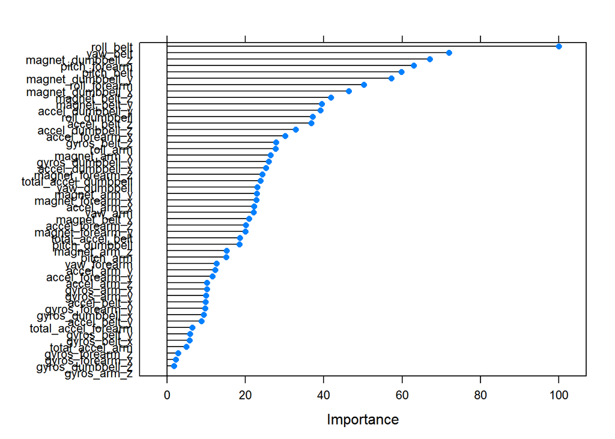

```r
plot( varImp(rfmodel) )
```

## Prepare the submission.

(using COURSERA provided code)

Perform validation on validation set and create result files for submission.

```r
pml_write_files = function(x){
      n = length(x)
      for(i in 1:n){
            filename = paste0("problem_id_",i,".txt")
            write.table(x[i],file=filename,quote=FALSE,row.names=FALSE,col.names=FALSE)
      }
}

x <- validation_set[,-53]

answers <- predict(rfmodel, newdata=x)
##answers
pml_write_files(answers)
```